# EDA Overview

## Transaction by States

```r
trans_profile_address_df %>%
  group_by(State) %>%
  summarise(transactions = sum(TRANS_COUNT),
            trans_2023 = sum(TRANS_COUNT_2023),
            trans_2024 = sum(TRANS_COUNT_2024),
            difference = trans_2024-trans_2023,
            pctg_change = round(((trans_2024-trans_2023)/trans_2023) * 100,2)) %>%
  arrange(desc(transactions))
```

```
## # A tibble: 1 × 6
##   State transactions trans_2023 trans_2024 difference pctg_change
##   <lgl>        <int>      <int>      <int>      <int>       <dbl>
## 1 NA         1045540     526394     519146      -7248       -1.38
```

This table shows the total transactions for each year per state. `trans_2023` is all the transactions that occurred in 2023 while `trans_2024` is all the transactions that occured in 2024.

The `difference` column represents the change in transactions from 2023 to 2024 while `pctg_change` represents this difference as percentages.

### Transactions by State Visualizations

#### Yearly Transactions by State

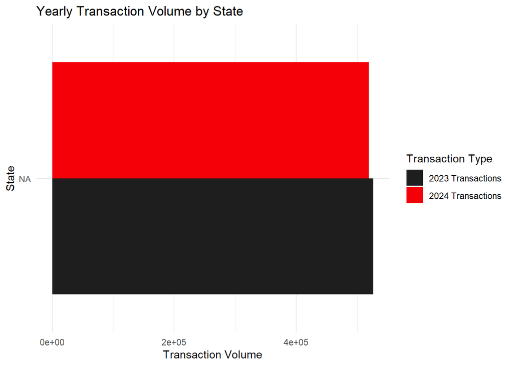

```r
# Assign changes from table to new dataframe
trans_summary <- trans_profile_address_df %>%
  group_by(State) %>%
  summarise(transactions = sum(TRANS_COUNT),
            trans_2023 = sum(TRANS_COUNT_2023),
            trans_2024 = sum(TRANS_COUNT_2024),
            difference = trans_2024 - trans_2023,
            pctg_change = round(((trans_2024 - trans_2023) / trans_2023) * 100, 2)) %>%
  arrange(desc(transactions)) %>%
  pivot_longer(cols = c(trans_2023, trans_2024), # Pivot the dataframe for easier plotting
               names_to = "Metric", values_to = "Value")


ggplot(trans_summary, aes(x = State, y = Value, fill = Metric)) +
  geom_col(position = "dodge") +  # Dodge to separate bars
  theme_minimal() +
  labs(title = "Yearly Transaction Volume by State",
       y = "Transaction Volume",
       x = "State",
       fill = "Transaction Type") +
  coord_flip() +
  scale_fill_manual(values = c("trans_2023" = "#1E1E1E", "trans_2024" = "#F40009"),
                    labels = c("2023 Transactions","2024 Transactions"))
```

This graph shows the Transaction Volume by State for 2023 and 2024.